# Théorème de la limite centrale

Hamza Snoussi

2022-01-22

Le théorème de la limite centrale indique que pour une variable aléatoire qu’on s’interesse quelle que soit la forme de la distribution de la population, plus la taille de l’échantillon croît, plus la distribution de la moyenne d’échantillonnage est proche d’une gaussienne (loi normale) et sa dispersion est donnée par le théorème central limite.

C’est-à-dire si $X \sim {\sf Loi-inconnue}(moyenne, equart-type)$ et $n$ est assez grand alors la variable aléatoire $\overline{X}$ qui prend a chaque fois qu’on effectue un échantillon la moyenne arithmétique de la variable X, suit une **loi normale** de paramèteres $\mu_{\overline{X}} = \mu_{{X}}$ et $\sigma_{\overline{X}} = \frac{\sigma_{X}}{\sqrt{n}}$

Dans ce qui suit on va simuler l’échantillonnage de variables aléatoire de loi autre que la loi normale, on va répéter cette action et on va enregistrer a chaque fois la moyenne des obsérvations et on pourra donc visualiser comment se comporte la distribution de la moyenne d’échantillonnage $\overline{X}$.

### Exemple, Loi uniforme :

On suppose que $X$ est variable aléatoire qui suit une loi uniforme on écrit donc : Soit $X \sim {\sf Unif}(a, b)$ tel que $a$ et $b$ sont les bornes min/max de la v.a $X$ pour simuler un échantillon aléatoire on fixe on fixe $a = 0$ et $b = 100$ on suppose aussi que la popoulation globale est de taille N = 12 million

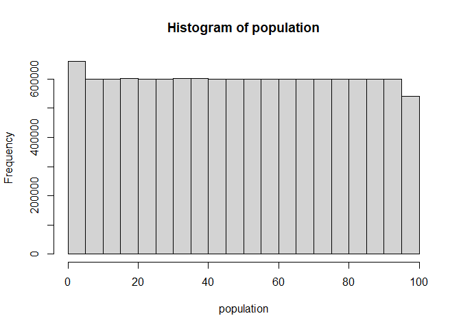

```r
# génération de 12 millon observation d'une variable de loi uniforme (arrondis a un entier)
population <- round(runif(min = 0 , max = 100 , n = 12000000 ))
# Creation d'un histogram pour visualiser le résultat
hist(population)
```

L’objet “population” représente la population globale théorique, on s’intéresse a faire des échantillons de taille $n = 100$ et enregistrer la moyenne des 100 observations, on va boucler dans ce process pour simuler une répétition de l’échantillonnage.

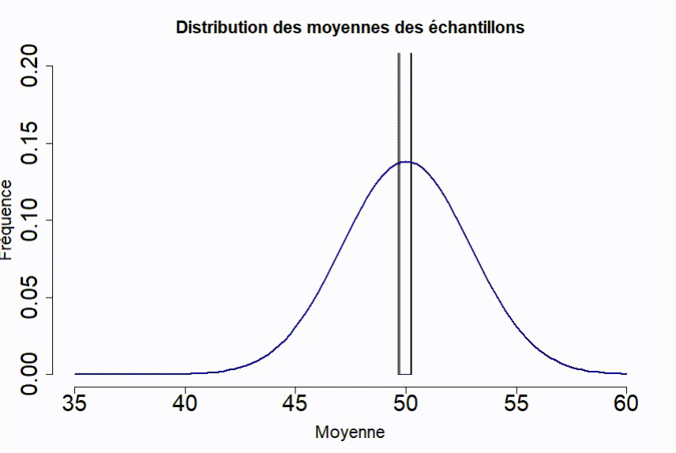

```r
muPop <- mean(population)
sdPop <- sd(population)
muXbar <- NA
n = 100
for(i in 1:1000){
  echantillon <- sample(x = population,size = n)
  muXbar[i] <- mean(echantillon)
  par(cex.main=1.5,cex.lab = 1.5)
  hist(muXbar,probability = T,
       main = "Distribution des moyennes des échantillons",
       xlab = "Moyenne",
       ylab = "Fréquence",
       xlim = c(35,60) , ylim = c(0,0.2))
  curve(dnorm(x, mean=muPop, sd=sdPop/sqrt(n)),col="darkblue", lwd=2, add=TRUE, yaxt="n")
  Sys.sleep(0.05)
}
```

On voit que lorsqu’on n est assez grand et qu’on répète l’échantillonnage un grand nombre de fois, la distribution des moyennes des échantillons est approximativement gaussienne.

### Loi Exponentielle

Soit $X \sim {\sf Exp}(\lambda)$

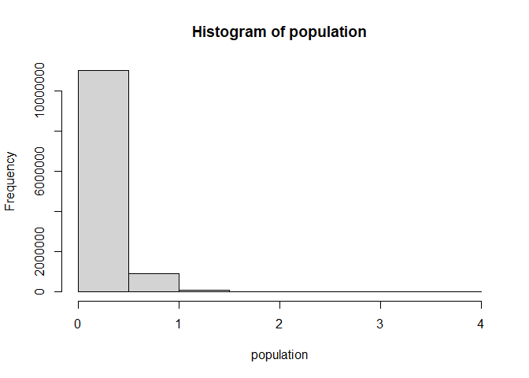

```r
# notre population théorique comme dans le cas précedent est de taille 12 million.
population <- round(rexp(n = 12000000 ,rate = 5 ),3)
# on peut donc avoir le vrai moyenne et equart type de toute la population
muPop <- mean(population)
sdPop <- sd(population)
# Visualiser la distribution de notre variable X
hist(population,breaks = 10)
```

On fait les memes procedure que dans le cas précédent, et on obtient cette démonstration graphique :

[figure not shown]

Apres avoir effectué 1000 échantillons de taille $n = 100$ on obtient cette distribution des moyennes des échantillons :

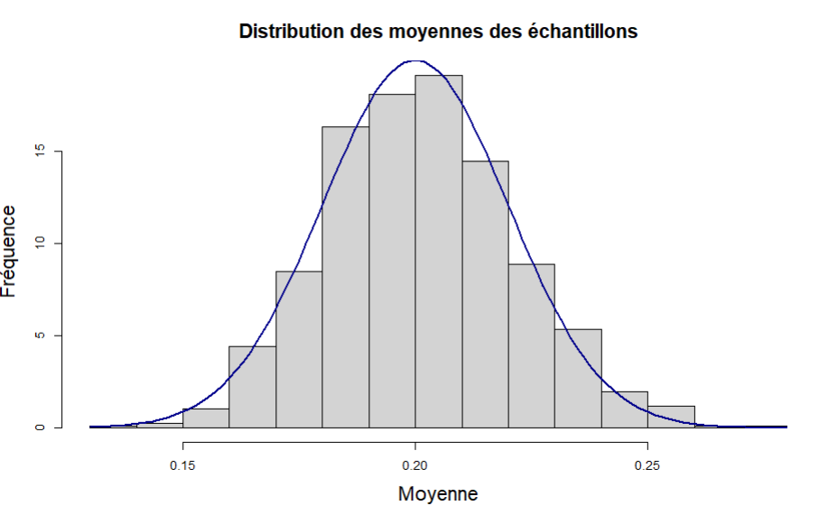